# Notes on using Stata

## Aggregating data

Suppose that we wanted to know the sample size, mean and standard deviation of our `y` variables within groups defined by `z1` and `z2`. We could type `bysort z1 z2: sum y*`, but what if we wanted it in a format that we could add to our original (or some other) dataset?

We could also do this using the collapse command:

```stata
. preserve

. collapse (mean) y1_mean=y1 y2_mean=y2 y3_mean=y3 ///
>   (sd) y1_sd = y1 y2_sd = y2 y3_sd = y3 ///
>   (count) y1_n = y1 y2_n = y2 y3_n = y3, by(z1 z2)

. list y1_mean y1_sd z1 z2 in 1/5

     ┌────────────────────────────────┐
     │   y1_mean      y1_sd   z1   z2 │
     ├────────────────────────────────┤
  1. │         .          .    1    1 │
  2. │ -.2085993    2.67239    1    2 │
  3. │ -.3881125          .    1    3 │
  4. │  .6914923   1.573746    1    4 │
  5. │   .641409   .2880112    1    5 │
     └────────────────────────────────┘

. restore
```

Here is a little loop-and-macro trick to avoid having to type all of these new variable names:

```
local mean (mean)
local sd (sd)
local n (count)
foreach x of varlist y* {
  local mean `mean' `x'_mean=`x'
  local sd `sd' `x'_sd=`x'
  local n `n' `x'_n=`x'
}
collapse `mean' `sd' `n'
```

If we are mainly interested in adding these aggregate statistics to our original dataset, we can also use the `egen` (*extended generate*) commands. For example, we can add the mean of `y1` within groups using

```stata
. egen y1_mean = mean(y1), by(z1 z2)
(2 missing values generated)
```

and similarly for the other variables and statistics (of course we could use loops and macros to automate the process). There are many useful `egen commands`. For example, `group` creates a variable indicating membership in groups defined by multiple categorical variables, and `total` gives the sum of a variable within groups. See `help egen` for more.

# Analysis

## Descriptive statistics

We’ve already seen how to use the `summarize` command, along with the `bysort` prefix, to get summaries of variables. You can also use the `detail` option with `summarize` to get more detailed statistics:

```stata
. use data.dta, clear

. sum y1, d

                             y1
─────────────────────────────────────────────────────────────
      Percentiles      Smallest
 1%    -2.152447      -2.152447
 5%    -1.871239      -2.098264
10%    -1.545414      -1.871239       Obs                  50
25%    -.8429845      -1.720355       Sum of wgt.          50

50%     .1392209                      Mean          -.0256222
                        Largest       Std. dev.      1.043069
75%      .560402       1.388999
90%      1.28302       1.681066       Variance       1.087994
95%     1.681066       1.839705       Skewness       -.258056
99%     1.904308       1.904308       Kurtosis       2.313607
```

```stata
. tab z1

         z1 │      Freq.     Percent        Cum.
────────────┼───────────────────────────────────
          1 │         10       20.00       20.00
          2 │         10       20.00       40.00
          3 │         11       22.00       62.00
          4 │         12       24.00       86.00
          5 │          7       14.00      100.00
────────────┼───────────────────────────────────
      Total │         50      100.00

. tab z1 z2, row col

┌───────────────────┐
│ Key               │
├───────────────────┤
│     frequency     │
│  row percentage   │
│ column percentage │
└───────────────────┘

           │                           z2
        z1 │         1          2          3          4          5 │     Total
───────────┼───────────────────────────────────────────────────────┼──────────
         1 │         0          2          1          4          3 │        10
           │      0.00      20.00      10.00      40.00      30.00 │    100.00
           │      0.00      25.00      10.00      30.77      33.33 │     20.00
───────────┼───────────────────────────────────────────────────────┼──────────
         2 │         3          1          4          1          1 │        10
           │     30.00      10.00      40.00      10.00      10.00 │    100.00
           │     30.00      12.50      40.00       7.69      11.11 │     20.00
───────────┼───────────────────────────────────────────────────────┼──────────
         3 │         2          2          0          4          3 │        11
           │     18.18      18.18       0.00      36.36      27.27 │    100.00
           │     20.00      25.00       0.00      30.77      33.33 │     22.00
───────────┼───────────────────────────────────────────────────────┼──────────
         4 │         3          1          4          3          1 │        12
           │     25.00       8.33      33.33      25.00       8.33 │    100.00
           │     30.00      12.50      40.00      23.08      11.11 │     24.00
───────────┼───────────────────────────────────────────────────────┼──────────
         5 │         2          2          1          1          1 │         7
           │     28.57      28.57      14.29      14.29      14.29 │    100.00
           │     20.00      25.00      10.00       7.69      11.11 │     14.00
───────────┼───────────────────────────────────────────────────────┼──────────
     Total │        10          8         10         13          9 │        50
           │     20.00      16.00      20.00      26.00      18.00 │    100.00
           │    100.00     100.00     100.00     100.00     100.00 │    100.00
```

There are several ways to obtain formatted tables of descriptive statistics, including the `dtable`, `table` and `collect` commands in more recent versions of Stata and the `outreg2` and `tabstat` packages (see German Rodriguez’s tutorial for a nice introduction to the `dtable` and `table` approaches). I usually find that, unless they are very simple, descriptive and regression tables need manual editing, so I just try to get the statistics into Excel so that I can format them, then export them from there.[^3]

Here’s how you can use `outreg2` (which is simple and works with any version of Stata) to get basic descriptives (overall, and by group; we need to clear saved estimates or they’ll be included in the table):

```
estimates clear
outreg2 using descriptives.txt, replace sum(log) keep(y1-y3)
bysort z1: outreg2 using descriptives.txt, sum(log) keep(y1-y3)
```

## Visualizing data

Stata has more extensive graphing capabilities than can be done justice in a short tutorial. Here, we’ll highlight some basic examples. See `help graph` for more, and remember that you can always use the graphical user interface to figure out the syntax.

You can create a basic histogram using `hist y1` or a basic scatterplot using `scatter y1 x1`. There are many options for customizing your graphs (you can also type `help graph`, or use the graphical interface to explore them in case you forget the syntax).

Below are some more complicated examples that I adapted from [*R for Data Science*](https://r4ds.hadley.nz). Here is a scatterplot of `y1` on `x1` with the color of the points determined by `z1`, a linear fit with confidence intervals, and labeled axes:

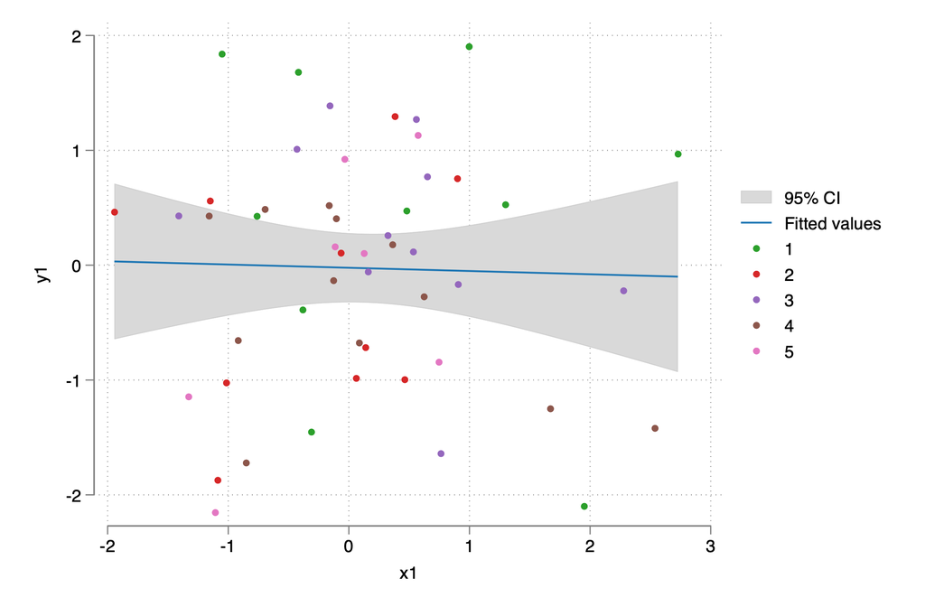

Scatterplot of `y1` against `x1`

```stata
. levelsof z1, local(z1)
1 2 3 4 5

. foreach x of local z1 {
  2.   gen y1_`x' = y1 if z1==`x'
  3.   label variable y1_`x' "`x'"
  4. }
(40 missing values generated)
(40 missing values generated)
(39 missing values generated)
(38 missing values generated)
(43 missing values generated)

. twoway (lfitci y1 x1) (scatter y1_1-y1_5 x1), ///
>   ytitle("y1") xtitle("x1") ///
>   scheme(white_tableau)

. graph export scatter1.png, replace
file /Users/johngardner/Library/CloudStorage/Box-Box/OleMissTeaching/StatComp/NotesOnStata/scatter1.png saved as
    PNG format
```

Above, we used the `levelsof` command to save the levels of `z1` in a local macro, then created separate `y1` variables for each value of `z1` as a trick to customize the color of the points (it’s possible to manually specify the shape and color of the points, but this approach changes the color automatically). We also used the user-written `white_tableau` scheme to style the graph. Normally, I’d save the graph as a PDF, but a PNG works better for the web.

We can also create separate subplots for each level of a variable:

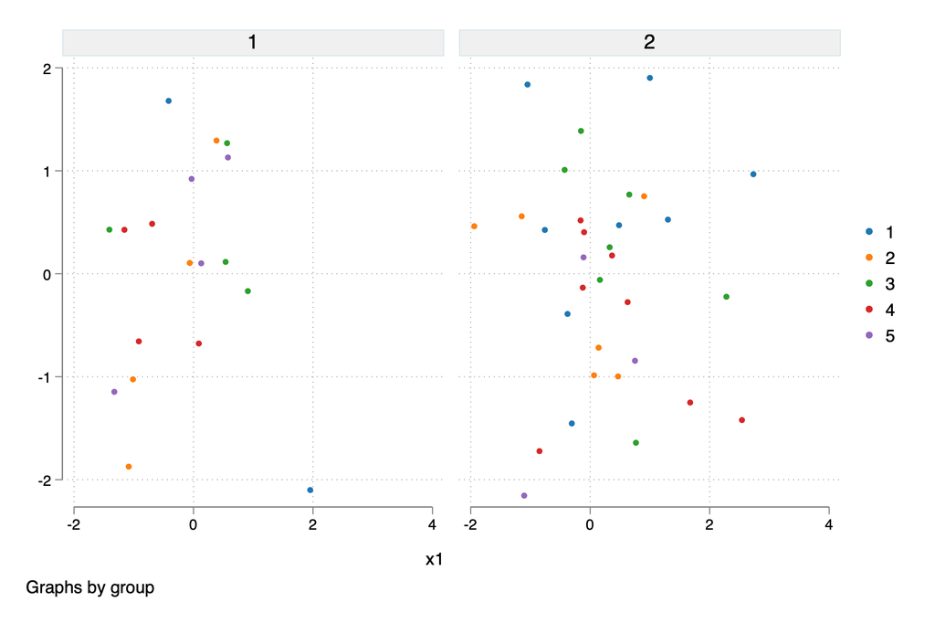

Scatterplot of `y1` against `x1` by `group`

```stata
. gen group = 1*(z2<3) + 2*(z2>=3)

. tw (scatter y1_1-y1_5 x1), by(group, legend(position(3))) scheme(white_tableau)

. graph export scatter2.png, replace
file /Users/johngardner/Library/CloudStorage/Box-Box/OleMissTeaching/StatComp/NotesOnStata/scatter2.png saved as
    PNG format
```

Here is a bar graph of `z1`, broken down by group:

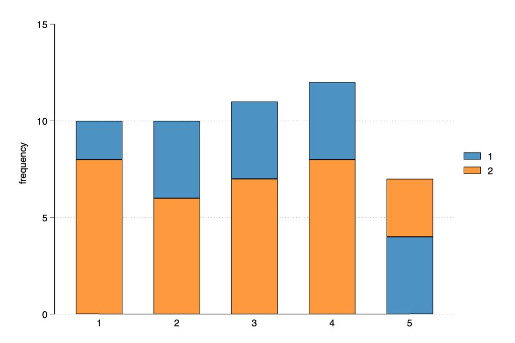

Bar graph of `z1` by `group`

```stata
. graph bar (count), over(group, sort(1) descending) over(z1) ///
>   stack asyvars scheme(white_tableau)

. graph export bar.png, replace
file /Users/johngardner/Library/CloudStorage/Box-Box/OleMissTeaching/StatComp/NotesOnStata/bar.png saved as PNG
    format
```

Here, `over(group, sort(1) descending)` breaks the bars down by groups, sorts them in (descending) order of the first *yvar*, which is `group`. The second `over` command makes separate bars for each value of `z1`. The `stack` and `asyvars` options tells Stata to treat `group` as a `yvar`, but to `stack` the “sub-bars” instead of putting them side by side.

Finally, here are kernel density estimates of `y1` by `group`, using a `recast` trick to fill the graphs (I don’t recall where I learned this):

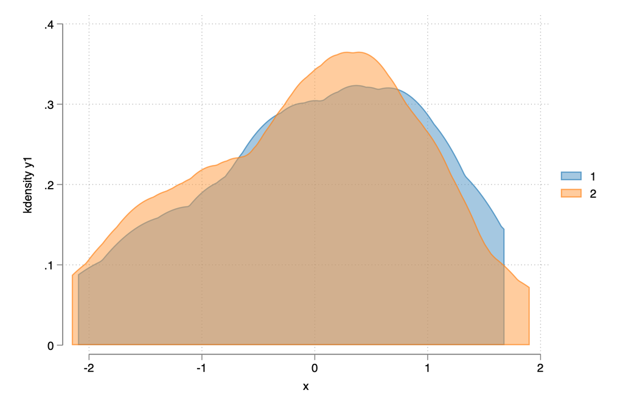

Kernel densities of `y1` by `group`

```stata
. graph tw (kdensity y1 if group==1, recast(area) color(%50)) ///
>   (kdensity y1 if group==2, recast(area) color(%50)), ///
>   legend(order(1 "1" 2 "2")) scheme(white_tableau)

. graph export kdensity.png, replace
file /Users/johngardner/Library/CloudStorage/Box-Box/OleMissTeaching/StatComp/NotesOnStata/kdensity.png saved as
    PNG format
```

If `group` had many values, we could automate this using a loop/macro trick similar to the one we used for collapse:

```
forvalues i=1/2 {
  local plottext  ///
    " `plottext' (kdensity y1 if group==`i', recast(area) color(%50)) "
  local legendtext `" `legendtext' `i' "`i'" "'
}
graph tw `plottext', legend(order(`legendtext')) ///
  scheme(white_tableau)
```

You can often use the `by` option to put multiple plots into the same image, as in the examples above. You can also use the `graph save graphname` and `graph combine` to save graphs in Stata’s format in order to make a table of graphs (or go to `Graphics > Table of graphs`).

We can also use Stata to plot functions. As an example, here are the densities for normal distributions with different variances:

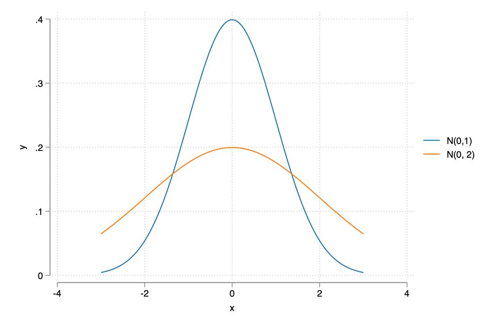

Densities for two normal distributions

```stata
. twoway (function normalden(x, 1), range(-3 3)) ///
>   (function normalden(x, 2), range(-3 3)),  ///
>   scheme(white_tableau) ///
>   legend(order(1 "N(0,1)" 2 "N(0, 2)"))

. graph export densities.png, replace
file /Users/johngardner/Library/CloudStorage/Box-Box/OleMissTeaching/StatComp/NotesOnStata/densities.png saved as
    PNG format
```

## Regression basics

Stata has extensive facilities for regressions and other statistical and econometric estimators. Here, we will only touch on the essentials.

You can run a regression using the `regress` command:

```stata
. reg y1 x1 x2 x3

      Source │       SS           df       MS      Number of obs   =        50
─────────────┼──────────────────────────────────   F(3, 46)        =      0.83
       Model │  2.73693139         3  .912310463   Prob > F        =    0.4843
    Residual │  50.5747722        46  1.09945157   R-squared       =    0.0513
─────────────┼──────────────────────────────────   Adj R-squared   =   -0.0105
       Total │  53.3117036        49  1.08799395   Root MSE        =    1.0485

─────────────┬────────────────────────────────────────────────────────────────
          y1 │ Coefficient  Std. err.      t    P>|t|     [95% conf. interval]
─────────────┼────────────────────────────────────────────────────────────────
          x1 │  -.0664044    .150171    -0.44   0.660     -.368683    .2358742
          x2 │   .0154261    .157254     0.10   0.922    -.3011098     .331962
          x3 │  -.2594343   .1678957    -1.55   0.129    -.5973908    .0785221
       _cons │  -.0120578   .1498728    -0.08   0.936    -.3137361    .2896204
─────────────┴────────────────────────────────────────────────────────────────
```

You can save the residuals using `predict resids_name, r` and predicted values using `predict prediction_name, xb`.

It’s easy to get robust or clustered standard errors:

```stata
. reg y1 x*, robust

Linear regression                               Number of obs     =         50
                                                F(3, 46)          =       0.78
                                                Prob > F          =     0.5098
                                                R-squared         =     0.0513
                                                Root MSE          =     1.0485

─────────────┬────────────────────────────────────────────────────────────────
             │               Robust
          y1 │ Coefficient  std. err.      t    P>|t|     [95% conf. interval]
─────────────┼────────────────────────────────────────────────────────────────
          x1 │  -.0664044    .164943    -0.40   0.689    -.3984175    .2656087
          x2 │   .0154261   .1379679     0.11   0.911     -.262289    .2931412
          x3 │  -.2594343   .1844303    -1.41   0.166    -.6306732    .1118046
       _cons │  -.0120578   .1523839    -0.08   0.937    -.3187907    .2946751
─────────────┴────────────────────────────────────────────────────────────────

. reg y1 x*, vce(cluster z1)

Linear regression                               Number of obs     =         50
                                                F(3, 4)           =       1.58
                                                Prob > F          =     0.3257
                                                R-squared         =     0.0513
                                                Root MSE          =     1.0485

                                     (Std. err. adjusted for 5 clusters in z1)
─────────────┬────────────────────────────────────────────────────────────────
             │               Robust
          y1 │ Coefficient  std. err.      t    P>|t|     [95% conf. interval]
─────────────┼────────────────────────────────────────────────────────────────
          x1 │  -.0664044   .1724878    -0.38   0.720    -.5453072    .4124985
          x2 │   .0154261   .0610512     0.25   0.813    -.1540791    .1849313
          x3 │  -.2594343   .1455596    -1.78   0.149    -.6635725    .1447039
       _cons │  -.0120578   .1846531    -0.07   0.951    -.5247369    .5006212
─────────────┴────────────────────────────────────────────────────────────────
```

You can use `test` to perform hypothesis tests on the most recently estimated model. Stata stores the coefficients and standard errors as scalars labelled `_b[varname]` and `_se[varname]`, which you can use with the `nlcom` command to test nonlinear hypotheses:

```stata
. reg y1 x*

      Source │       SS           df       MS      Number of obs   =        50
─────────────┼──────────────────────────────────   F(3, 46)        =      0.83
       Model │  2.73693139         3  .912310463   Prob > F        =    0.4843
    Residual │  50.5747722        46  1.09945157   R-squared       =    0.0513
─────────────┼──────────────────────────────────   Adj R-squared   =   -0.0105
       Total │  53.3117036        49  1.08799395   Root MSE        =    1.0485

─────────────┬────────────────────────────────────────────────────────────────
          y1 │ Coefficient  Std. err.      t    P>|t|     [95% conf. interval]
─────────────┼────────────────────────────────────────────────────────────────
          x1 │  -.0664044    .150171    -0.44   0.660     -.368683    .2358742
          x2 │   .0154261    .157254     0.10   0.922    -.3011098     .331962
          x3 │  -.2594343   .1678957    -1.55   0.129    -.5973908    .0785221
       _cons │  -.0120578   .1498728    -0.08   0.936    -.3137361    .2896204
─────────────┴────────────────────────────────────────────────────────────────

. test x1=x2

 ( 1)  x1 - x2 = 0

       F(  1,    46) =    0.16
            Prob > F =    0.6871

. nlcom _b[x1]^2 - _b[x2]

       _nl_1: _b[x1]^2 - _b[x2]

─────────────┬────────────────────────────────────────────────────────────────
          y1 │ Coefficient  Std. err.      z    P>|z|     [95% conf. interval]
─────────────┼────────────────────────────────────────────────────────────────
       _nl_1 │  -.0110166   .1612239    -0.07   0.946    -.3270096    .3049765
─────────────┴────────────────────────────────────────────────────────────────
```

You can also store estimates to refer to them later:

```stata
. qui reg y1 x*

. estimates store model1

. // several commands later
. est replay model1

───────────────────────────────────────────────────────────────────────────────────────────────────────────────────
Model model1
───────────────────────────────────────────────────────────────────────────────────────────────────────────────────

      Source │       SS           df       MS      Number of obs   =        50
─────────────┼──────────────────────────────────   F(3, 46)        =      0.83
       Model │  2.73693139         3  .912310463   Prob > F        =    0.4843
    Residual │  50.5747722        46  1.09945157   R-squared       =    0.0513
─────────────┼──────────────────────────────────   Adj R-squared   =   -0.0105
       Total │  53.3117036        49  1.08799395   Root MSE        =    1.0485

─────────────┬────────────────────────────────────────────────────────────────
          y1 │ Coefficient  Std. err.      t    P>|t|     [95% conf. interval]
─────────────┼────────────────────────────────────────────────────────────────
          x1 │  -.0664044    .150171    -0.44   0.660     -.368683    .2358742
          x2 │   .0154261    .157254     0.10   0.922    -.3011098     .331962
          x3 │  -.2594343   .1678957    -1.55   0.129    -.5973908    .0785221
       _cons │  -.0120578   .1498728    -0.08   0.936    -.3137361    .2896204
─────────────┴────────────────────────────────────────────────────────────────

. estimates restore model1
(results model1 are active now)

. test x1=x2

 ( 1)  x1 - x2 = 0

       F(  1,    46) =    0.16
            Prob > F =    0.6871
```

You can type `ereturn list` to see a list of all of the macros, scalars, and matrices that are stored after a regression or other estimation command:

```stata
. eret li

scalars:
               e(rank) =  4
               e(ll_0) =  -72.5502487097244
                 e(ll) =  -71.23267351705861
               e(r2_a) =  -.0105309582061384
                e(rss) =  50.57477224345187
                e(mss) =  2.736931388681441
               e(rmse) =  1.048547362072798
                 e(r2) =  .051338284133013
                  e(F) =  .8297868567969474
               e(df_r) =  46
               e(df_m) =  3
                  e(N) =  50

macros:
            e(cmdline) : "regress y1 x*"
              e(title) : "Linear regression"
          e(marginsok) : "XB default"
                e(vce) : "ols"
             e(depvar) : "y1"
                e(cmd) : "regress"
         e(properties) : "b V"
            e(predict) : "regres_p"
              e(model) : "ols"
          e(estat_cmd) : "regress_estat"

matrices:
                  e(b) :  1 x 4
                  e(V) :  4 x 4
               e(beta) :  1 x 3

functions:
             e(sample)
```

The following includes `x1`, its square, its interaction with `x2` and `x3`, its interactions with indicators for the levels of `z1` and `z2`, as well as those levels themselves:

```stata
. reg y1 c.x1##c.x2 c.x1#c.x1 c.x1#c.x3 c.x1#(i.z1 i.z2) i.z1 i.z2

      Source │       SS           df       MS      Number of obs   =        50
─────────────┼──────────────────────────────────   F(21, 28)       =      0.63
       Model │  17.1054571        21  .814545578   Prob > F        =    0.8609
    Residual │  36.2062465        28  1.29308023   R-squared       =    0.3209
─────────────┼──────────────────────────────────   Adj R-squared   =   -0.1885
       Total │  53.3117036        49  1.08799395   Root MSE        =    1.1371

─────────────┬────────────────────────────────────────────────────────────────
          y1 │ Coefficient  Std. err.      t    P>|t|     [95% conf. interval]
─────────────┼────────────────────────────────────────────────────────────────
          x1 │   .5119097   .7865183     0.65   0.520      -1.0992    2.123019
          x2 │  -.0607202   .1949629    -0.31   0.758    -.4600835    .3386431
             │
   c.x1#c.x2 │  -.1240336   .2620448    -0.47   0.640    -.6608081    .4127408
             │
   c.x1#c.x1 │  -.0610364   .1938742    -0.31   0.755    -.4581696    .3360968
             │
   c.x1#c.x3 │   .1742655   .3160815     0.55   0.586     -.473198     .821729
             │
     z1#c.x1 │
          2  │   .2831985   .7956912     0.36   0.725    -1.346701    1.913098
          3  │  -.4193324   .6628734    -0.63   0.532    -1.777167    .9385023
          4  │  -.5098121   .6056266    -0.84   0.407    -1.750382    .7307577
          5  │   1.111535   .8050032     1.38   0.178    -.5374398    2.760509
             │
     z2#c.x1 │
          2  │  -.9379134   .8095513    -1.16   0.256    -2.596204    .7203772
          3  │  -.9040705   .7688583    -1.18   0.250    -2.479005    .6708643
          4  │   -.341652   .7850846    -0.44   0.667    -1.949825    1.266521
          5  │  -.3200915   .9607607    -0.33   0.741    -2.288121    1.647938
             │
          z1 │
          2  │  -.8286218    .613738    -1.35   0.188    -2.085807    .4285634
          3  │  -.2705119   .5653038    -0.48   0.636    -1.428484    .8874603
          4  │  -.8410675   .5970149    -1.41   0.170    -2.063997     .381862
          5  │  -.6799663   .6402059    -1.06   0.297    -1.991369    .6314361
             │
          z2 │
          2  │  -.4950503   .6344122    -0.78   0.442    -1.794585    .8044843
          3  │  -.3736093   .5497722    -0.68   0.502    -1.499767     .752548
          4  │  -.1426655   .5691045    -0.25   0.804    -1.308423    1.023092
          5  │  -.6368414   .6884577    -0.93   0.363    -2.047083    .7734003
             │
       _cons │   .9144687   .6497817     1.41   0.170    -.4165487    2.245486
─────────────┴────────────────────────────────────────────────────────────────
```

We can use the margins command to find the marginal effect of `x1` after all of those terms:

```stata
. margins, dydx(x1)

Average marginal effects                                    Number of obs = 50
Model VCE: OLS

Expression: Linear prediction, predict()
dy/dx wrt:  x1

─────────────┬────────────────────────────────────────────────────────────────
             │            Delta-method
             │      dy/dx   std. err.      t    P>|t|     [95% conf. interval]
─────────────┼────────────────────────────────────────────────────────────────
          x1 │   .0346223   .2021769     0.17   0.865    -.3795183    .4487629
─────────────┴────────────────────────────────────────────────────────────────
```

To estimate a probit and the average marginal effects of its regressors, we can use

```stata
. gen y_bin = (y1 >= 0)

. probit y_bin x*

Iteration 0:   log likelihood =  -34.29649
Iteration 1:   log likelihood = -33.507899
Iteration 2:   log likelihood = -33.507377
Iteration 3:   log likelihood = -33.507377

Probit regression                                       Number of obs =     50
                                                        LR chi2(3)    =   1.58
                                                        Prob > chi2   = 0.6643
Log likelihood = -33.507377                             Pseudo R2     = 0.0230

─────────────┬────────────────────────────────────────────────────────────────
       y_bin │ Coefficient  Std. err.      z    P>|z|     [95% conf. interval]
─────────────┼────────────────────────────────────────────────────────────────
          x1 │  -.1689203   .1844929    -0.92   0.360    -.5305196    .1926791
          x2 │    .033874   .1931569     0.18   0.861    -.3447066    .4124546
          x3 │  -.1891183   .2024053    -0.93   0.350    -.5858253    .2075888
       _cons │   .1793668   .1821691     0.98   0.325    -.1776781    .5364117
─────────────┴────────────────────────────────────────────────────────────────

. margins, dydx(*)

Average marginal effects                                    Number of obs = 50
Model VCE: OIM

Expression: Pr(y_bin), predict()
dy/dx wrt:  x1 x2 x3

─────────────┬────────────────────────────────────────────────────────────────
             │            Delta-method
             │      dy/dx   std. err.      z    P>|z|     [95% conf. interval]
─────────────┼────────────────────────────────────────────────────────────────
          x1 │  -.0649794   .0691144    -0.94   0.347    -.2004411    .0704823
          x2 │   .0130305    .074224     0.18   0.861    -.1324458    .1585068
          x3 │  -.0727491    .075812    -0.96   0.337    -.2213379    .0758398
─────────────┴────────────────────────────────────────────────────────────────
```

```
qui reg y1 x1
outreg2 using results.txt, replace
qui reg y1 x1 x2
outreg2 using results.txt
qui reg y1 x*
outreg2 using results.txt
```

The result will look similar to the results from Stata’s `etable` command:

```stata
. qui reg y1 x1

. est sto m1

. qui reg y1 x1 x2

. est sto m2

. qui reg y1 x*

. est sto m3

. etable, estimates(m1 m2 m3) mstat(r2)

─────────────────────────────────
             y1      y1      y1
─────────────────────────────────
x1         -0.028  -0.024  -0.066
          (0.147) (0.150) (0.150)
x2                  0.040   0.015
                  (0.159) (0.157)
x3                         -0.259
                          (0.168)
Intercept  -0.023  -0.019  -0.012
          (0.150) (0.152) (0.150)
R-squared    0.00    0.00    0.05
─────────────────────────────────
```

We can also loop over different dependent variables (below, we use a loop/macro trick to make sure we only use the `replace` option once by redefining the macro `replace` to be empty after the first model):

```
local replace replace
foreach y of varlist y1 y2 y3 {
  qui reg `y' x*
  outreg2 using results2.txt, `replace'
  local replace
}
```

Some other useful regression commands that you should be aware of are:

- `ivregress` and the `ivreg2` package for instrumental variables and two-stage least squares
- `xtreg` for panel data models including fixed and random effects
- `areg` for fixed effects models
- The `reghdfe` package for models with lots of fixed effects
- The `coefplot` package for plotting model coefficients

# Matrix algebra basics*

There are two ways to work with matrices in Stata: using the original matrix commands, or using the matrix commands that come with Stata’s programming language, Mata. If you are going to do advanced computational work in Stata, you should probably learn about Mata. Here we’ll only briefly touch on the original commands. See `help matrix` for more detail.

Stata matrix commands have to be prefaced by `matrix`. You can create and view a matrix using

```stata
. mat A = (1, 2 \ 3, 4)

. mat list A

A[2,2]
    c1  c2
r1   1   2
r2   3   4
```

You can subset a matrix using

```stata
. mat B = A[1, 1..2]

. mat C = A[1..., 2]

. mat li B

B[1,2]
    c1  c2
r1   1   2

. mat li C

C[2,1]
    c2
r1   2
r2   4
```

You can get the transpose and inverse of a matrix using:

```stata
. mat A_t = A'

. mat A_inv = inv(A)

. mat li A_t

A_t[2,2]
    r1  r2
c1   1   3
c2   2   4

. mat li A_inv

A_inv[2,2]
     r1   r2
c1   -2    1
c2  1.5  -.5
```

Often, you want to create a matrix from variables in a dataset. You can do this using the `mkmat` command (we use the variable `one` to add a constant at the end):

```stata
. drop if mi(y1) // drop missing values introduced from merge
(0 observations deleted)

. gen one = 1

. mkmat x* one, matrix(X)
```

Stata has commands to efficiently create matrix products. To obtain *X*′*X* or *y*<sub>1</sub>′*X* we can use the following (by default, these will also include a constant term, which can be suppressed using the `noconstant` option; there are also commands for weighted cross products, see `help matrix accum`):

```stata
. matrix accum XX = x*
(obs=50)

. matrix vecaccum y1X = y1 x*
```

You can also multiply and add matrices. For example, we could regress `y1` on `x1`-`x3` using

```stata
. mat beta_hat = inv(XX) * y1X'

. mat li beta_hat

beta_hat[4,1]
               y1
   x1  -.06640435
   x2   .01542611
   x3  -.25943432
_cons  -.01205783
```

and obtain the (default) standard errors as

```stata
. mkmat y1, matrix(y1)

. mat e = y1 - X*beta_hat

. local n: rowsof y1

. local k: colsof X

. mat vcov = inv(XX) * (e' * e)/(`n' - `k')

. mat li vcov

symmetric vcov[4,4]
               x1          x2          x3       _cons
   x1   .02255134
   x2   .00326241   .02472883
   x3   .00463959   .00263781   .02818895
_cons  -.00222657   .00211105  -.00075217   .02246185
```

We can compare this to the variance matrix from the `regress` command:

```stata
. qui reg y1 x*

. mat li e(V)

symmetric e(V)[4,4]
               x1          x2          x3       _cons
   x1   .02255134
   x2   .00326241   .02472883
   x3   .00463959   .00263781   .02818895
_cons  -.00222657   .00211105  -.00075217   .02246185
```

# Resources for more

- German Rodriguez’s [Stata tutorial](https://grodri.github.io/stata/index) is a great place to learn more about Stata (and how I originally learned)[^4]
- Kit Baum’s [A little Stata programming goes a long way](http://fmwww.bc.edu/ec-p/wp612.pdf) is a nice introduction to basic Stata programming
- *An introduction to Stata programming* by Baum is a more comprehensive resource on Stata programming
- The official Stata documentation is available at https://www.stata.com/features/documentation/, and also comes bundled with Stata
[^1]: You can also manually install a package by downloading the files placing them your personal ado directory (see https://www.stata.com/support/faqs/programming/personal-ado-directory/).
[^2]: Since we just created it, we know that the data are already sorted in terms of `z1`, but if we weren’t sure, we would use `sort z1` before this step.
[^3]: You can get tables from spreadsheets into Excel by pasting into LyX and exporting a LaTeX file, or by using the Excel2LaTeX plugin.
[^4]: I also created this document using his [Markstat](https://grodri.github.io/markstat/) package.